# VRP APP

### Synopsis

Application that solves the Capacitated Vehicle Routing Problem. The problem information is provided through an excel (*.xlsx) document, which should contain the geographical locations of a central depot and a set of client nodes. The demands from the client nodes should also be included in the file, where the demand from the depot should be set as zero. Once a file is loaded, the program automatically determines the cost matrices and geometries associated to the network. The user should select the type of optimization to be carried out (with respect to distance or time), in the side panel through the radio buttons. The maximum capacity of the vehicles from the fleet should also be written on a specific box on the side panel. When the user has already provided the data for the problem, the programs can be executed using the action button that is also displayed on the side panel. The application provides a table indicating the order of the routes that are included in the optimal solution with its corresponding distance travelled, time taken and total demand delivered. A graphical solution is also provided which is based on geospatial information taken from OpenStreetMap databases. The routines executed within the application are based on the “Savings” and “Branch and Bound” algorithms. The osrm package was employed in order to create the cost matrices and route geometries. The leaflet package was employed to create an interactive map widget showing the routes and the nodes involved in the problem.

### Example

The *.xlsx file should provide the information in the format specified in the template below, where the first column corresponds to the nodes identification names, the second row corresponds to Latitude, the third to Longitude and the fourth column contains the demands from all the nodes (terminal has zero demand).

[output not shown]

Once the file is uploaded, the problem data is displayed in the “Problem Information” panel.

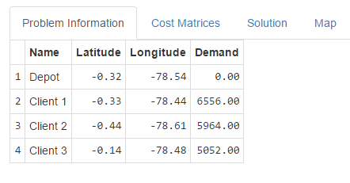

The program calculates the time and distance matrices upon the given data and they are displayed in the “Cost Matrices” panel.

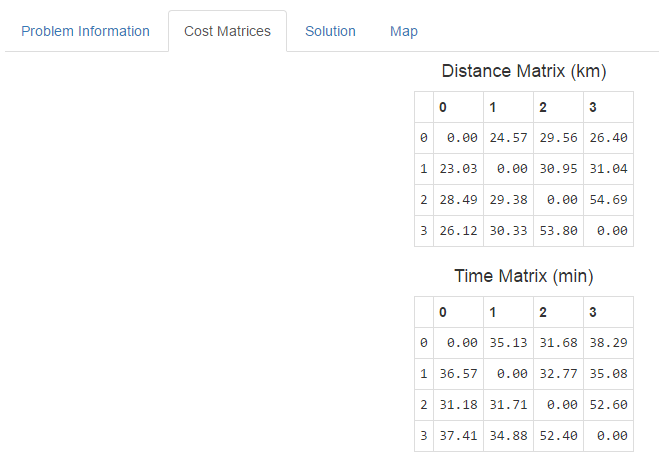

The routes order and numeric results are arranged in a table that is displayed in the “Solution” panel.

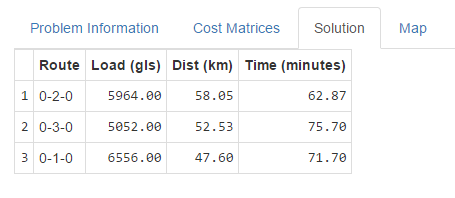

Capacity is set to “10000 gal”. The cost is set to “Distance”. After execution a base map is plotted along with all the routes in the optimal solution and displayed in the “map” panel.

[figure not shown]

### Motivation

The application was developed under the project: “Optimization model for road freight heavy transport in Ecuador” that is being administered by the Transport Department of the National Institute of Energy Efficiency and Renewable Energy (INER).

### Data License Attribution

The geospatial data is made available under the Open Database License: http://opendatacommons.org/licenses/odbl/1.0/. Any rights in individual contents of the database are licensed under the Database Contents License: http://opendatacommons.org/licenses/dbcl/1.0/

For more information please refer to:

https://github.com/Project-OSRM/osrm-backend/wiki/Api-usage-policy

### About the authors

For more information on the project please contact the authors at:

Patricio Gallardo Email: patricio.gallardo@iner.gob.ec

Paúl León Email: paul.leon@iner.gob.ec

### License

All rights are reserved to INER.